# Risk Factor Analysis

## Outcome Variable

**Outcome Variable:** wast_rec90d

## Predictor Variables

**Intervention Variable:** predfeed36

**Adjustment Set:**

- arm
- sex
- month
- brthmon
- W_mage
- meducyrs
- feducyrs
- hhwealth_quart
- hfoodsec
- W_mhtcm
- vagbrth
- W_birthwt
- W_birthlen
- W_nrooms
- W_nchldlt5
- W_parity
- impfloor
- impsan
- safeh20
- delta_W_mage
- delta_meducyrs
- delta_feducyrs
- delta_hhwealth_quart
- delta_hfoodsec
- delta_W_mhtcm
- delta_vagbrth
- delta_W_birthwt
- delta_W_birthlen
- delta_W_nrooms
- delta_W_nchldlt5
- delta_W_parity
- delta_impfloor
- delta_impsan
- delta_safeh20

## Stratifying Variables

The analysis was stratified on these variable(s):

- agecat
- studyid
- country

## Data Summary

| agecat | studyid | country | predfeed36 | wast_rec90d | n_cell | n |
| --- | --- | --- | --- | --- | --- | --- |
| 0-24 months | ki0047075b-MAL-ED | BANGLADESH | 1 | 0 | 25 | 122 |
| 0-24 months | ki0047075b-MAL-ED | BANGLADESH | 1 | 1 | 44 | 122 |
| 0-24 months | ki0047075b-MAL-ED | BANGLADESH | 0 | 0 | 19 | 122 |
| 0-24 months | ki0047075b-MAL-ED | BANGLADESH | 0 | 1 | 34 | 122 |
| 0-24 months | ki0047075b-MAL-ED | BRAZIL | 1 | 0 | 1 | 23 |
| 0-24 months | ki0047075b-MAL-ED | BRAZIL | 1 | 1 | 0 | 23 |
| 0-24 months | ki0047075b-MAL-ED | BRAZIL | 0 | 0 | 5 | 23 |
| 0-24 months | ki0047075b-MAL-ED | BRAZIL | 0 | 1 | 17 | 23 |
| 0-24 months | ki0047075b-MAL-ED | INDIA | 1 | 0 | 2 | 177 |
| 0-24 months | ki0047075b-MAL-ED | INDIA | 1 | 1 | 10 | 177 |
| 0-24 months | ki0047075b-MAL-ED | INDIA | 0 | 0 | 68 | 177 |
| 0-24 months | ki0047075b-MAL-ED | INDIA | 0 | 1 | 97 | 177 |
| 0-24 months | ki0047075b-MAL-ED | NEPAL | 1 | 0 | 1 | 93 |
| 0-24 months | ki0047075b-MAL-ED | NEPAL | 1 | 1 | 5 | 93 |
| 0-24 months | ki0047075b-MAL-ED | NEPAL | 0 | 0 | 19 | 93 |
| 0-24 months | ki0047075b-MAL-ED | NEPAL | 0 | 1 | 68 | 93 |
| 0-24 months | ki0047075b-MAL-ED | PERU | 1 | 0 | 1 | 32 |
| 0-24 months | ki0047075b-MAL-ED | PERU | 1 | 1 | 5 | 32 |
| 0-24 months | ki0047075b-MAL-ED | PERU | 0 | 0 | 5 | 32 |
| 0-24 months | ki0047075b-MAL-ED | PERU | 0 | 1 | 21 | 32 |
| 0-24 months | ki0047075b-MAL-ED | SOUTH AFRICA | 1 | 0 | 0 | 78 |
| 0-24 months | ki0047075b-MAL-ED | SOUTH AFRICA | 1 | 1 | 0 | 78 |
| 0-24 months | ki0047075b-MAL-ED | SOUTH AFRICA | 0 | 0 | 13 | 78 |
| 0-24 months | ki0047075b-MAL-ED | SOUTH AFRICA | 0 | 1 | 65 | 78 |
| 0-24 months | ki0047075b-MAL-ED | TANZANIA, UNITED REPUBLIC OF | 1 | 0 | 0 | 45 |
| 0-24 months | ki0047075b-MAL-ED | TANZANIA, UNITED REPUBLIC OF | 1 | 1 | 0 | 45 |
| 0-24 months | ki0047075b-MAL-ED | TANZANIA, UNITED REPUBLIC OF | 0 | 0 | 8 | 45 |
| 0-24 months | ki0047075b-MAL-ED | TANZANIA, UNITED REPUBLIC OF | 0 | 1 | 37 | 45 |
| 0-24 months | ki1000109-EE | PAKISTAN | 1 | 0 | 80 | 255 |
| 0-24 months | ki1000109-EE | PAKISTAN | 1 | 1 | 66 | 255 |

[output cut: 126 more lines]

The following strata were considered:

- agecat: 0-24 months, studyid: ki0047075b-MAL-ED, country: BANGLADESH
- agecat: 0-24 months, studyid: ki0047075b-MAL-ED, country: BRAZIL
- agecat: 0-24 months, studyid: ki0047075b-MAL-ED, country: INDIA
- agecat: 0-24 months, studyid: ki0047075b-MAL-ED, country: NEPAL
- agecat: 0-24 months, studyid: ki0047075b-MAL-ED, country: PERU
- agecat: 0-24 months, studyid: ki0047075b-MAL-ED, country: SOUTH AFRICA
- agecat: 0-24 months, studyid: ki0047075b-MAL-ED, country: TANZANIA, UNITED REPUBLIC OF
- agecat: 0-24 months, studyid: ki1000109-EE, country: PAKISTAN
- agecat: 0-24 months, studyid: ki1000304b-SAS-FoodSuppl, country: INDIA
- agecat: 0-24 months, studyid: ki1113344-GMS-Nepal, country: NEPAL
- agecat: 0-24 months, studyid: ki1148112-LCNI-5, country: MALAWI
- agecat: 0-24 months, studyid: kiGH5241-JiVitA-3, country: BANGLADESH
- agecat: 0-24 months, studyid: kiGH5241-JiVitA-4, country: BANGLADESH
- agecat: 0-6 months, studyid: ki0047075b-MAL-ED, country: BANGLADESH
- agecat: 0-6 months, studyid: ki0047075b-MAL-ED, country: BRAZIL
- agecat: 0-6 months, studyid: ki0047075b-MAL-ED, country: INDIA
- agecat: 0-6 months, studyid: ki0047075b-MAL-ED, country: NEPAL
- agecat: 0-6 months, studyid: ki0047075b-MAL-ED, country: PERU
- agecat: 0-6 months, studyid: ki0047075b-MAL-ED, country: SOUTH AFRICA
- agecat: 0-6 months, studyid: ki0047075b-MAL-ED, country: TANZANIA, UNITED REPUBLIC OF
- agecat: 0-6 months, studyid: ki1000109-EE, country: PAKISTAN
- agecat: 0-6 months, studyid: ki1000304b-SAS-FoodSuppl, country: INDIA
- agecat: 0-6 months, studyid: ki1113344-GMS-Nepal, country: NEPAL
- agecat: 0-6 months, studyid: ki1148112-LCNI-5, country: MALAWI
- agecat: 0-6 months, studyid: kiGH5241-JiVitA-3, country: BANGLADESH
- agecat: 0-6 months, studyid: kiGH5241-JiVitA-4, country: BANGLADESH
- agecat: 6-24 months, studyid: ki0047075b-MAL-ED, country: BANGLADESH
- agecat: 6-24 months, studyid: ki0047075b-MAL-ED, country: BRAZIL
- agecat: 6-24 months, studyid: ki0047075b-MAL-ED, country: INDIA
- agecat: 6-24 months, studyid: ki0047075b-MAL-ED, country: NEPAL
- agecat: 6-24 months, studyid: ki0047075b-MAL-ED, country: PERU
- agecat: 6-24 months, studyid: ki0047075b-MAL-ED, country: SOUTH AFRICA
- agecat: 6-24 months, studyid: ki0047075b-MAL-ED, country: TANZANIA, UNITED REPUBLIC OF
- agecat: 6-24 months, studyid: ki1000109-EE, country: PAKISTAN
- agecat: 6-24 months, studyid: ki1000304b-SAS-FoodSuppl, country: INDIA
- agecat: 6-24 months, studyid: ki1113344-GMS-Nepal, country: NEPAL
- agecat: 6-24 months, studyid: ki1148112-LCNI-5, country: MALAWI
- agecat: 6-24 months, studyid: kiGH5241-JiVitA-3, country: BANGLADESH
- agecat: 6-24 months, studyid: kiGH5241-JiVitA-4, country: BANGLADESH

### Dropped Strata

Some strata were dropped due to rare outcomes:

- agecat: 0-24 months, studyid: ki0047075b-MAL-ED, country: BRAZIL
- agecat: 0-24 months, studyid: ki0047075b-MAL-ED, country: INDIA
- agecat: 0-24 months, studyid: ki0047075b-MAL-ED, country: NEPAL
- agecat: 0-24 months, studyid: ki0047075b-MAL-ED, country: PERU
- agecat: 0-24 months, studyid: ki0047075b-MAL-ED, country: SOUTH AFRICA
- agecat: 0-24 months, studyid: ki0047075b-MAL-ED, country: TANZANIA, UNITED REPUBLIC OF
- agecat: 0-24 months, studyid: ki1000304b-SAS-FoodSuppl, country: INDIA
- agecat: 0-24 months, studyid: ki1148112-LCNI-5, country: MALAWI
- agecat: 0-6 months, studyid: ki0047075b-MAL-ED, country: BRAZIL
- agecat: 0-6 months, studyid: ki0047075b-MAL-ED, country: INDIA
- agecat: 0-6 months, studyid: ki0047075b-MAL-ED, country: NEPAL
- agecat: 0-6 months, studyid: ki0047075b-MAL-ED, country: PERU
- agecat: 0-6 months, studyid: ki0047075b-MAL-ED, country: SOUTH AFRICA
- agecat: 0-6 months, studyid: ki0047075b-MAL-ED, country: TANZANIA, UNITED REPUBLIC OF
- agecat: 0-6 months, studyid: ki1000304b-SAS-FoodSuppl, country: INDIA
- agecat: 0-6 months, studyid: ki1148112-LCNI-5, country: MALAWI
- agecat: 6-24 months, studyid: ki0047075b-MAL-ED, country: BRAZIL
- agecat: 6-24 months, studyid: ki0047075b-MAL-ED, country: INDIA
- agecat: 6-24 months, studyid: ki0047075b-MAL-ED, country: NEPAL
- agecat: 6-24 months, studyid: ki0047075b-MAL-ED, country: PERU
- agecat: 6-24 months, studyid: ki0047075b-MAL-ED, country: SOUTH AFRICA
- agecat: 6-24 months, studyid: ki0047075b-MAL-ED, country: TANZANIA, UNITED REPUBLIC OF
- agecat: 6-24 months, studyid: ki1000304b-SAS-FoodSuppl, country: INDIA
- agecat: 6-24 months, studyid: ki1148112-LCNI-5, country: MALAWI
- agecat: 6-24 months, studyid: kiGH5241-JiVitA-3, country: BANGLADESH

## Methods Detail

We’re interested in the causal parameters $E[Y_a]$ for all values of $a \in \mathcal{A}$. These parameters represent the mean outcome if, possibly contrary to fact, we intervened to set all units to have $A=a$. Under the randomization and positivity assumptions, these are identified by the statistical parameters $\psi_a=E_W[E_{Y|A,W}(Y|A=a,W)]$. In addition, we’re interested in the mean of $Y$, $E[Y]$ under no intervention (the observed mean). We will estimate these parameters by using SuperLearner to fit the relevant likelihood factors – $E_{Y|A,W}(Y|A=a,W)$ and $p(A=a|W)$, and then updating our likelihood fit using a joint TMLE.

For unadjusted analyses ($W=\{\}$), initial likelihoods were estimated using Lrnr_glm to estimate the simple $E(Y|A)$ and Lrnr_mean to estimate $p(A)$. For adjusted analyses, a small library containing Lrnr_glmnet, Lrnr_xgboost, and Lrnr_mean was used.

Having estimated these parameters, we will then use the delta method to estimate relative risks and attributable risks relative to a prespecified baseline level of $A$.

# Results Detail

## Results Plots

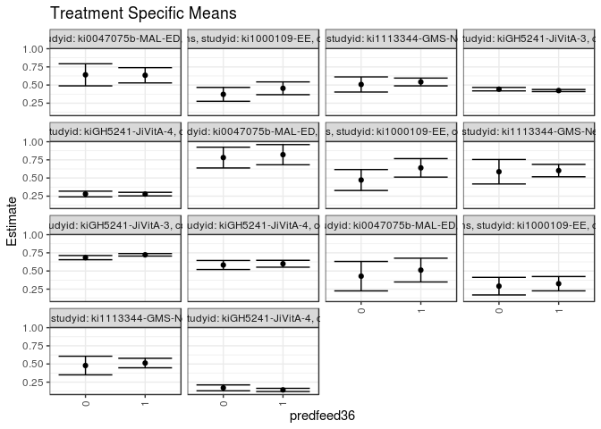

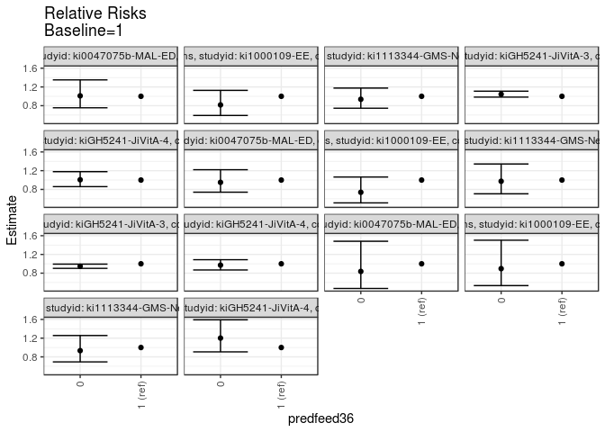

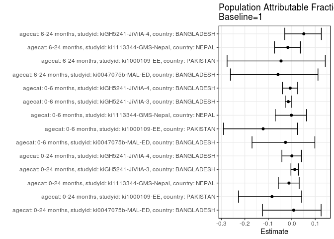

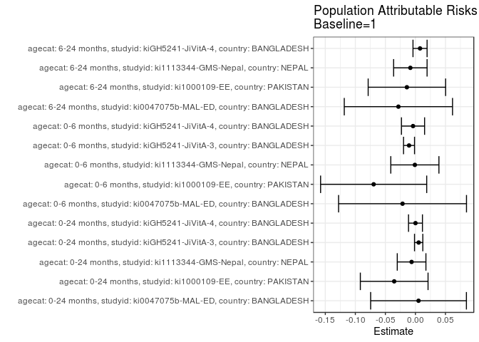

## Results Table

### Parameter: TSM

| agecat | studyid | country | intervention_level | baseline_level | estimate | ci_lower | ci_upper |
| --- | --- | --- | --- | --- | --- | --- | --- |
| 0-24 months | ki0047075b-MAL-ED | BANGLADESH | 1 | NA | 0.6341445 | 0.5292520 | 0.7390371 |
| 0-24 months | ki0047075b-MAL-ED | BANGLADESH | 0 | NA | 0.6405106 | 0.4884677 | 0.7925536 |
| 0-24 months | ki1000109-EE | PAKISTAN | 1 | NA | 0.4549260 | 0.3668678 | 0.5429843 |
| 0-24 months | ki1000109-EE | PAKISTAN | 0 | NA | 0.3713487 | 0.2757749 | 0.4669224 |
| 0-24 months | ki1113344-GMS-Nepal | NEPAL | 1 | NA | 0.5419234 | 0.4885044 | 0.5953423 |
| 0-24 months | ki1113344-GMS-Nepal | NEPAL | 0 | NA | 0.5075926 | 0.4035046 | 0.6116806 |
| 0-24 months | kiGH5241-JiVitA-3 | BANGLADESH | 1 | NA | 0.4237984 | 0.4093174 | 0.4382794 |
| 0-24 months | kiGH5241-JiVitA-3 | BANGLADESH | 0 | NA | 0.4427964 | 0.4190896 | 0.4665032 |
| 0-24 months | kiGH5241-JiVitA-4 | BANGLADESH | 1 | NA | 0.2780533 | 0.2534990 | 0.3026076 |
| 0-24 months | kiGH5241-JiVitA-4 | BANGLADESH | 0 | NA | 0.2798620 | 0.2408657 | 0.3188582 |
| 0-6 months | ki0047075b-MAL-ED | BANGLADESH | 1 | NA | 0.8214286 | 0.6823152 | 0.9605419 |
| 0-6 months | ki0047075b-MAL-ED | BANGLADESH | 0 | NA | 0.7812500 | 0.6381241 | 0.9243759 |
| 0-6 months | ki1000109-EE | PAKISTAN | 1 | NA | 0.6396180 | 0.5121959 | 0.7670400 |
| 0-6 months | ki1000109-EE | PAKISTAN | 0 | NA | 0.4723356 | 0.3279392 | 0.6167321 |
| 0-6 months | ki1113344-GMS-Nepal | NEPAL | 1 | NA | 0.6021468 | 0.5168637 | 0.6874298 |
| 0-6 months | ki1113344-GMS-Nepal | NEPAL | 0 | NA | 0.5865615 | 0.4181239 | 0.7549990 |
| 0-6 months | kiGH5241-JiVitA-3 | BANGLADESH | 1 | NA | 0.7228531 | 0.7055118 | 0.7401944 |
| 0-6 months | kiGH5241-JiVitA-3 | BANGLADESH | 0 | NA | 0.6841997 | 0.6552869 | 0.7131124 |
| 0-6 months | kiGH5241-JiVitA-4 | BANGLADESH | 1 | NA | 0.5996666 | 0.5523179 | 0.6470153 |
| 0-6 months | kiGH5241-JiVitA-4 | BANGLADESH | 0 | NA | 0.5823568 | 0.5199997 | 0.6447139 |
| 6-24 months | ki0047075b-MAL-ED | BANGLADESH | 1 | NA | 0.5121951 | 0.3484618 | 0.6759284 |
| 6-24 months | ki0047075b-MAL-ED | BANGLADESH | 0 | NA | 0.4285714 | 0.2258750 | 0.6312678 |
| 6-24 months | ki1000109-EE | PAKISTAN | 1 | NA | 0.3249896 | 0.2263573 | 0.4236219 |
| 6-24 months | ki1000109-EE | PAKISTAN | 0 | NA | 0.2912552 | 0.1700621 | 0.4124484 |
| 6-24 months | ki1113344-GMS-Nepal | NEPAL | 1 | NA | 0.5127885 | 0.4470885 | 0.5784885 |
| 6-24 months | ki1113344-GMS-Nepal | NEPAL | 0 | NA | 0.4784994 | 0.3503534 | 0.6066454 |
| 6-24 months | kiGH5241-JiVitA-4 | BANGLADESH | 1 | NA | 0.1425698 | 0.1207027 | 0.1644370 |
| 6-24 months | kiGH5241-JiVitA-4 | BANGLADESH | 0 | NA | 0.1712750 | 0.1308841 | 0.2116659 |

### Parameter: E(Y)

| agecat | studyid | country | intervention_level | baseline_level | estimate | ci_lower | ci_upper |
| --- | --- | --- | --- | --- | --- | --- | --- |
| 0-24 months | ki0047075b-MAL-ED | BANGLADESH | NA | NA | 0.6393443 | 0.5530901 | 0.7255985 |
| 0-24 months | ki1000109-EE | PAKISTAN | NA | NA | 0.4196078 | 0.3541827 | 0.4850330 |
| 0-24 months | ki1113344-GMS-Nepal | NEPAL | NA | NA | 0.5355731 | 0.4882587 | 0.5828875 |
| 0-24 months | kiGH5241-JiVitA-3 | BANGLADESH | NA | NA | 0.4292213 | 0.4164001 | 0.4420426 |
| 0-24 months | kiGH5241-JiVitA-4 | BANGLADESH | NA | NA | 0.2781828 | 0.2567503 | 0.2996153 |
| 0-6 months | ki0047075b-MAL-ED | BANGLADESH | NA | NA | 0.8000000 | 0.6995926 | 0.9004074 |
| 0-6 months | ki1000109-EE | PAKISTAN | NA | NA | 0.5700935 | 0.4742263 | 0.6659606 |
| 0-6 months | ki1113344-GMS-Nepal | NEPAL | NA | NA | 0.6012270 | 0.5255442 | 0.6769098 |
| 0-6 months | kiGH5241-JiVitA-3 | BANGLADESH | NA | NA | 0.7122532 | 0.6971343 | 0.7273720 |
| 0-6 months | kiGH5241-JiVitA-4 | BANGLADESH | NA | NA | 0.5957031 | 0.5531528 | 0.6382534 |
| 6-24 months | ki0047075b-MAL-ED | BANGLADESH | NA | NA | 0.4838710 | 0.3544124 | 0.6133295 |
| 6-24 months | ki1000109-EE | PAKISTAN | NA | NA | 0.3108108 | 0.2352987 | 0.3863229 |
| 6-24 months | ki1113344-GMS-Nepal | NEPAL | NA | NA | 0.5043732 | 0.4466684 | 0.5620780 |
| 6-24 months | kiGH5241-JiVitA-4 | BANGLADESH | NA | NA | 0.1502754 | 0.1309788 | 0.1695719 |

### Parameter: RR

| agecat | studyid | country | intervention_level | baseline_level | estimate | ci_lower | ci_upper |
| --- | --- | --- | --- | --- | --- | --- | --- |
| 0-24 months | ki0047075b-MAL-ED | BANGLADESH | 1 | 1 | 1.0000000 | 1.0000000 | 1.0000000 |
| 0-24 months | ki0047075b-MAL-ED | BANGLADESH | 0 | 1 | 1.0100388 | 0.7551515 | 1.3509586 |
| 0-24 months | ki1000109-EE | PAKISTAN | 1 | 1 | 1.0000000 | 1.0000000 | 1.0000000 |
| 0-24 months | ki1000109-EE | PAKISTAN | 0 | 1 | 0.8162836 | 0.5910802 | 1.1272903 |
| 0-24 months | ki1113344-GMS-Nepal | NEPAL | 1 | 1 | 1.0000000 | 1.0000000 | 1.0000000 |
| 0-24 months | ki1113344-GMS-Nepal | NEPAL | 0 | 1 | 0.9366502 | 0.7461157 | 1.1758411 |
| 0-24 months | kiGH5241-JiVitA-3 | BANGLADESH | 1 | 1 | 1.0000000 | 1.0000000 | 1.0000000 |
| 0-24 months | kiGH5241-JiVitA-3 | BANGLADESH | 0 | 1 | 1.0448279 | 0.9834049 | 1.1100872 |
| 0-24 months | kiGH5241-JiVitA-4 | BANGLADESH | 1 | 1 | 1.0000000 | 1.0000000 | 1.0000000 |
| 0-24 months | kiGH5241-JiVitA-4 | BANGLADESH | 0 | 1 | 1.0065048 | 0.8590315 | 1.1792953 |
| 0-6 months | ki0047075b-MAL-ED | BANGLADESH | 1 | 1 | 1.0000000 | 1.0000000 | 1.0000000 |
| 0-6 months | ki0047075b-MAL-ED | BANGLADESH | 0 | 1 | 0.9510870 | 0.7410793 | 1.2206068 |
| 0-6 months | ki1000109-EE | PAKISTAN | 1 | 1 | 1.0000000 | 1.0000000 | 1.0000000 |
| 0-6 months | ki1000109-EE | PAKISTAN | 0 | 1 | 0.7384653 | 0.5124187 | 1.0642292 |
| 0-6 months | ki1113344-GMS-Nepal | NEPAL | 1 | 1 | 1.0000000 | 1.0000000 | 1.0000000 |
| 0-6 months | ki1113344-GMS-Nepal | NEPAL | 0 | 1 | 0.9741171 | 0.7064363 | 1.3432268 |
| 0-6 months | kiGH5241-JiVitA-3 | BANGLADESH | 1 | 1 | 1.0000000 | 1.0000000 | 1.0000000 |
| 0-6 months | kiGH5241-JiVitA-3 | BANGLADESH | 0 | 1 | 0.9465265 | 0.9024048 | 0.9928056 |
| 0-6 months | kiGH5241-JiVitA-4 | BANGLADESH | 1 | 1 | 1.0000000 | 1.0000000 | 1.0000000 |
| 0-6 months | kiGH5241-JiVitA-4 | BANGLADESH | 0 | 1 | 0.9711343 | 0.8678120 | 1.0867581 |
| 6-24 months | ki0047075b-MAL-ED | BANGLADESH | 1 | 1 | 1.0000000 | 1.0000000 | 1.0000000 |
| 6-24 months | ki0047075b-MAL-ED | BANGLADESH | 0 | 1 | 0.8367347 | 0.4727681 | 1.4809056 |
| 6-24 months | ki1000109-EE | PAKISTAN | 1 | 1 | 1.0000000 | 1.0000000 | 1.0000000 |
| 6-24 months | ki1000109-EE | PAKISTAN | 0 | 1 | 0.8961986 | 0.5340528 | 1.5039186 |
| 6-24 months | ki1113344-GMS-Nepal | NEPAL | 1 | 1 | 1.0000000 | 1.0000000 | 1.0000000 |
| 6-24 months | ki1113344-GMS-Nepal | NEPAL | 0 | 1 | 0.9331321 | 0.6931294 | 1.2562380 |
| 6-24 months | kiGH5241-JiVitA-4 | BANGLADESH | 1 | 1 | 1.0000000 | 1.0000000 | 1.0000000 |
| 6-24 months | kiGH5241-JiVitA-4 | BANGLADESH | 0 | 1 | 1.2013413 | 0.9065538 | 1.5919861 |

### Parameter: PAR

| agecat | studyid | country | intervention_level | baseline_level | estimate | ci_lower | ci_upper |
| --- | --- | --- | --- | --- | --- | --- | --- |
| 0-24 months | ki0047075b-MAL-ED | BANGLADESH | 1 | NA | 0.0051997 | -0.0745253 | 0.0849247 |
| 0-24 months | ki1000109-EE | PAKISTAN | 1 | NA | -0.0353182 | -0.0916814 | 0.0210451 |
| 0-24 months | ki1113344-GMS-Nepal | NEPAL | 1 | NA | -0.0063502 | -0.0302077 | 0.0175073 |
| 0-24 months | kiGH5241-JiVitA-3 | BANGLADESH | 1 | NA | 0.0054229 | -0.0014685 | 0.0123143 |
| 0-24 months | kiGH5241-JiVitA-4 | BANGLADESH | 1 | NA | 0.0001295 | -0.0114615 | 0.0117206 |
| 0-6 months | ki0047075b-MAL-ED | BANGLADESH | 1 | NA | -0.0214286 | -0.1279114 | 0.0850542 |
| 0-6 months | ki1000109-EE | PAKISTAN | 1 | NA | -0.0695245 | -0.1578545 | 0.0188055 |
| 0-6 months | ki1113344-GMS-Nepal | NEPAL | 1 | NA | -0.0009198 | -0.0409868 | 0.0391473 |
| 0-6 months | kiGH5241-JiVitA-3 | BANGLADESH | 1 | NA | -0.0105999 | -0.0197570 | -0.0014428 |
| 0-6 months | kiGH5241-JiVitA-4 | BANGLADESH | 1 | NA | -0.0039635 | -0.0232144 | 0.0152874 |
| 6-24 months | ki0047075b-MAL-ED | BANGLADESH | 1 | NA | -0.0283242 | -0.1184390 | 0.0617907 |
| 6-24 months | ki1000109-EE | PAKISTAN | 1 | NA | -0.0141788 | -0.0786447 | 0.0502871 |
| 6-24 months | ki1113344-GMS-Nepal | NEPAL | 1 | NA | -0.0084153 | -0.0362645 | 0.0194338 |
| 6-24 months | kiGH5241-JiVitA-4 | BANGLADESH | 1 | NA | 0.0077055 | -0.0040258 | 0.0194369 |

### Parameter: PAF

| agecat | studyid | country | intervention_level | baseline_level | estimate | ci_lower | ci_upper |
| --- | --- | --- | --- | --- | --- | --- | --- |
| 0-24 months | ki0047075b-MAL-ED | BANGLADESH | 1 | NA | 0.0081329 | -0.1244954 | 0.1251184 |
| 0-24 months | ki1000109-EE | PAKISTAN | 1 | NA | -0.0841695 | -0.2272962 | 0.0422659 |
| 0-24 months | ki1113344-GMS-Nepal | NEPAL | 1 | NA | -0.0118569 | -0.0573884 | 0.0317140 |
| 0-24 months | kiGH5241-JiVitA-3 | BANGLADESH | 1 | NA | 0.0126343 | -0.0035523 | 0.0285599 |
| 0-24 months | kiGH5241-JiVitA-4 | BANGLADESH | 1 | NA | 0.0004656 | -0.0420827 | 0.0412767 |
| 0-6 months | ki0047075b-MAL-ED | BANGLADESH | 1 | NA | -0.0267857 | -0.1693195 | 0.0983739 |
| 0-6 months | ki1000109-EE | PAKISTAN | 1 | NA | -0.1219528 | -0.2906940 | 0.0247277 |
| 0-6 months | ki1113344-GMS-Nepal | NEPAL | 1 | NA | -0.0015298 | -0.0704414 | 0.0629455 |
| 0-6 months | kiGH5241-JiVitA-3 | BANGLADESH | 1 | NA | -0.0148822 | -0.0278380 | -0.0020897 |
| 0-6 months | kiGH5241-JiVitA-4 | BANGLADESH | 1 | NA | -0.0066535 | -0.0394795 | 0.0251359 |
| 6-24 months | ki0047075b-MAL-ED | BANGLADESH | 1 | NA | -0.0585366 | -0.2614024 | 0.1117032 |
| 6-24 months | ki1000109-EE | PAKISTAN | 1 | NA | -0.0456187 | -0.2755732 | 0.1428806 |
| 6-24 months | ki1113344-GMS-Nepal | NEPAL | 1 | NA | -0.0166847 | -0.0733294 | 0.0369706 |
| 6-24 months | kiGH5241-JiVitA-4 | BANGLADESH | 1 | NA | 0.0512762 | -0.0298901 | 0.1260456 |